# Land use and microbe prevalence jointly determine host-microbe network structure

Analysis and results

Matan Markfeld

Last edit: 2024-04-04

```r
source("modularity_analysis_functions.R", local = knitr::knit_global())
```

```r
# reading the microbiome data
# working only with Rattus from the three villages
# removing the 'village' grid from the analysis

data_asv <- read_csv("../data/data_processed/microbiome/data_asv_rra0.01_th1000.csv") %>%
  filter(host_species == "Rattus rattus" & grid!="village")

# # ASVs taxonomy
# asv_taxa <- read_delim("../data/data_raw/data_microbiome/ASVs_all_merged_taxonomy.tsv") %>%
#   select(ASV, Family)
# data_asv %<>% left_join(asv_taxa, by=c("asv_ID"="ASV"))
#
# data_asv_family <- data_asv %>%
#   group_by(host_ID, village, host_species, grid, season,total_reads, Family) %>%
#   summarise(reads = sum(reads)) %>%
#   rename(asv_ID = Family) %>%
#   filter(!(is.na(asv_ID)))
# data_asv <- data_asv_family
```

# 1 Modularity analysis

## 1.1 Network exploration

```r
# loop for three villages
for (i in 1:3) {

  cat('###',village_names[i],'{.tabset}','\n','\n')

  cat('#### ASVs degree distribution','\n')

  print(asv_degree_distribution_three_villages[[i]])
  cat('\n','\n')

  # calculating connectance
  connectance_data <- modules_table_three_villages %>%
    filter(village == village_names[i])

  cat('No. of hosts: ', length(unique(connectance_data$host_ID)) ,'\n','\n')
  cat('No. of ASVs: ', length(unique(connectance_data$asv_ID)) ,'\n','\n')
  cat('Connectance: ', nrow(connectance_data) / (length(unique(connectance_data$host_ID)) * length(unique(connectance_data$asv_ID))) ,'\n','\n')


  cat('#### Modules','\n')
  cat('The color indicates number of host individuals in the module / total number of hosts in the whole grid [%]','\n','\n')

  print(modules_three_villages[[i]])
  cat('\n','\n')

  cat('#### Modules size','\n')
  print(modules_size_three_villages[[i]])
  cat('\n','\n')

  cat('#### No. of land uses','\n')
  print(modules_grid_three_villages[[i]])
  cat('\n','\n')

}
```

### 1.1.1 Mandena

#### 1.1.1.1 ASVs degree distribution

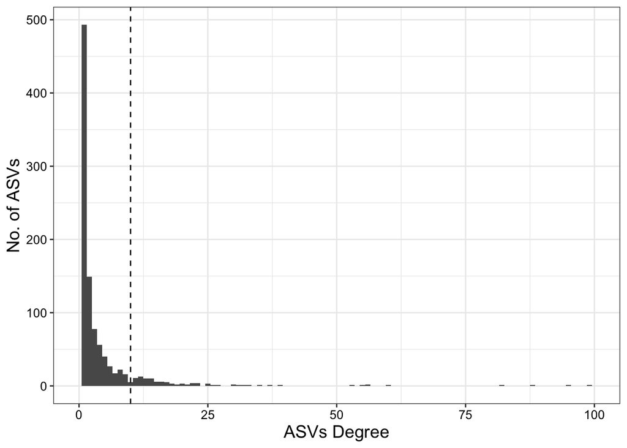

No. of hosts: 295

No. of ASVs: 1007

Connectance: 0.0159864

#### 1.1.1.2 Modules

The color indicates number of host individuals in the module / total number of hosts in the whole grid [%]

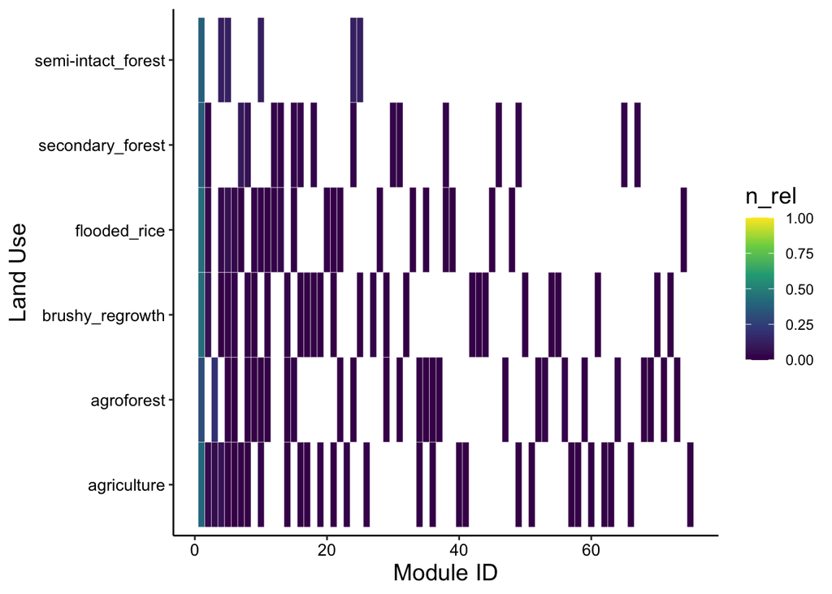

#### 1.1.1.3 Modules size

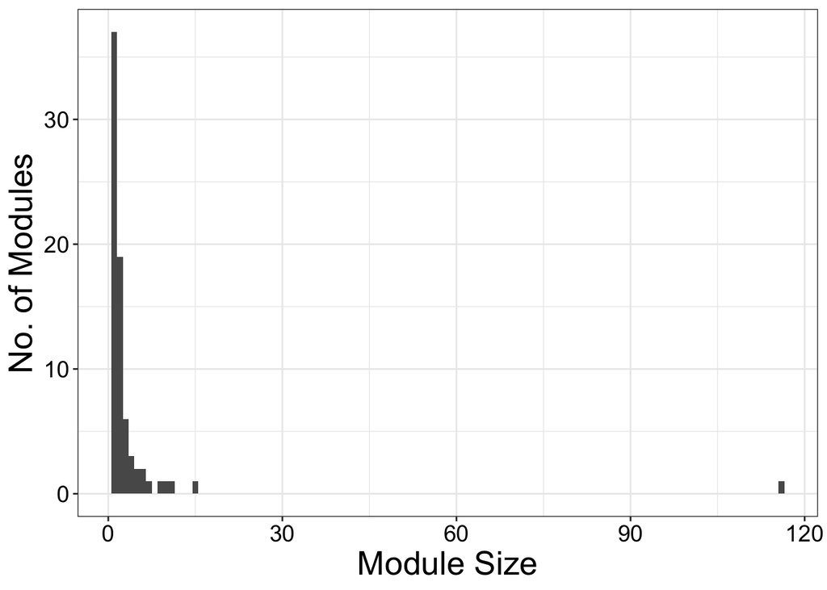

#### 1.1.1.4 No. of land uses

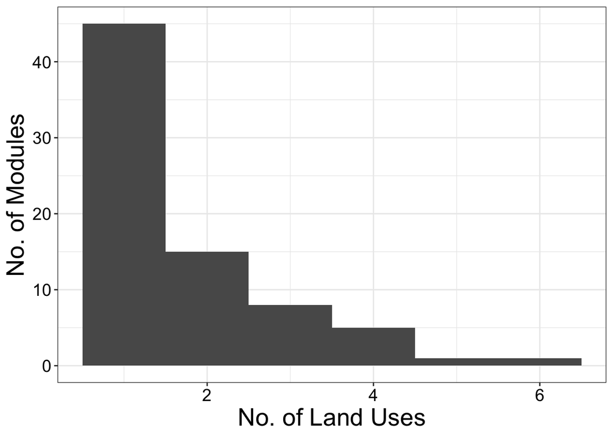

### 1.1.2 Sarahandrano

#### 1.1.2.1 ASVs degree distribution

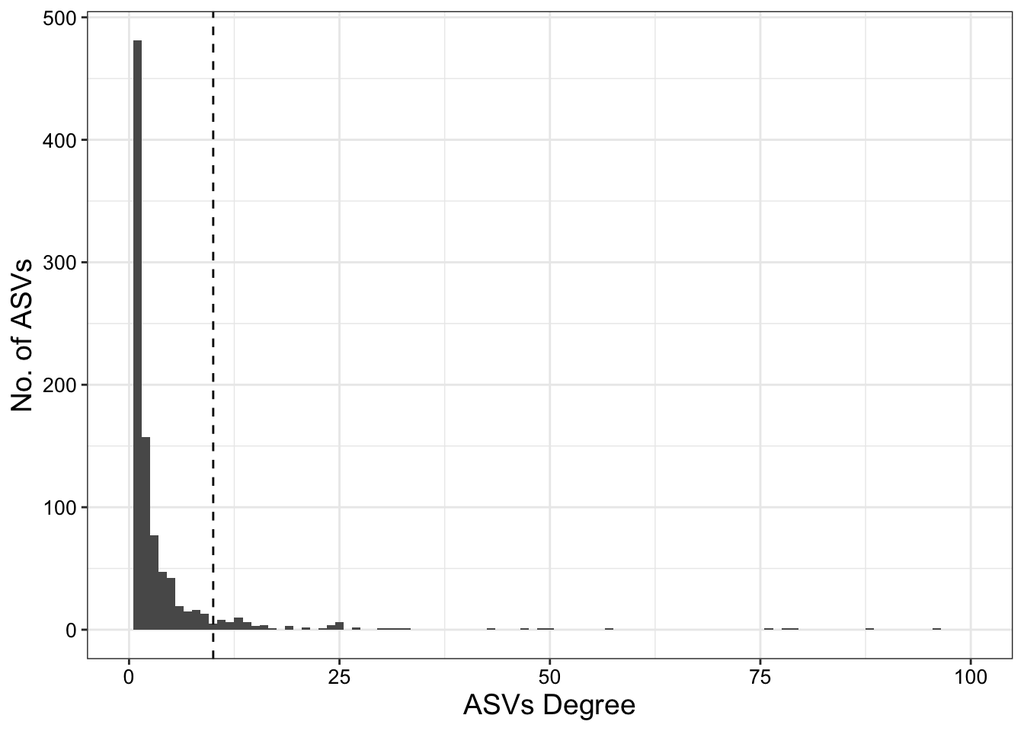

No. of hosts: 261

No. of ASVs: 944

Connectance: 0.01571125

#### 1.1.2.2 Modules

The color indicates number of host individuals in the module / total number of hosts in the whole grid [%]

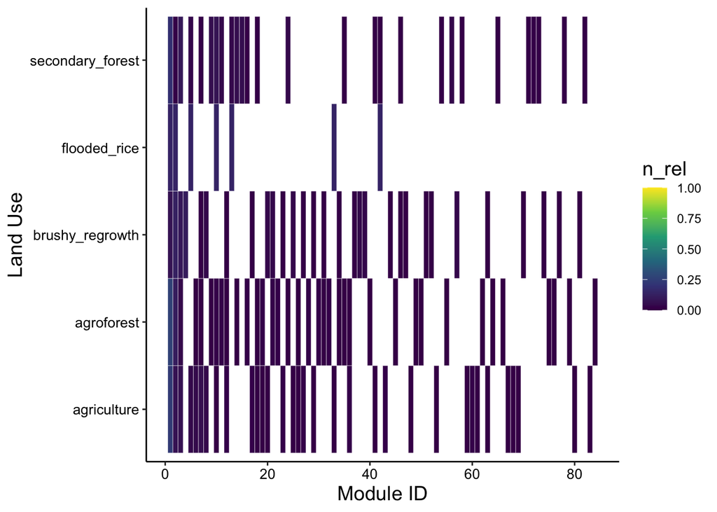

#### 1.1.2.3 Modules size

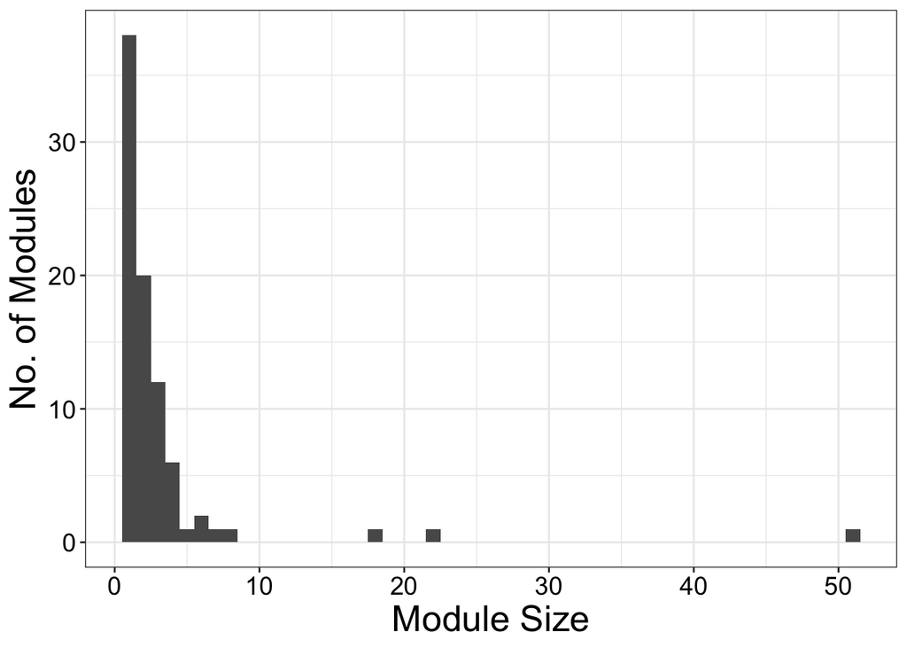

#### 1.1.2.4 No. of land uses

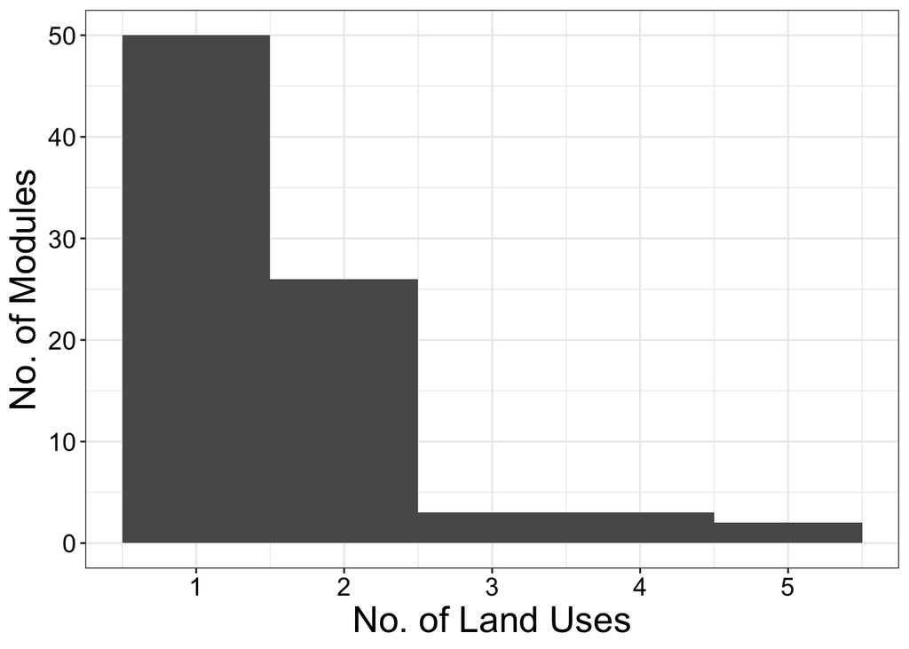

### 1.1.3 Andatsakala

#### 1.1.3.1 ASVs degree distribution

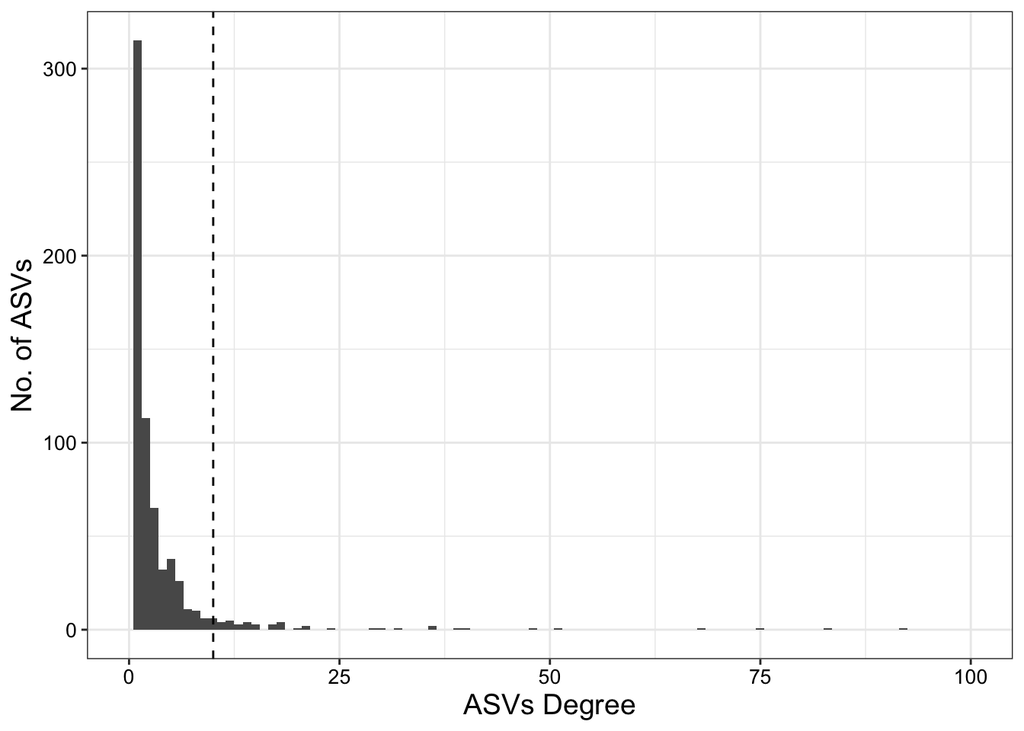

No. of hosts: 159

No. of ASVs: 665

Connectance: 0.02452357

#### 1.1.3.2 Modules

The color indicates number of host individuals in the module / total number of hosts in the whole grid [%]

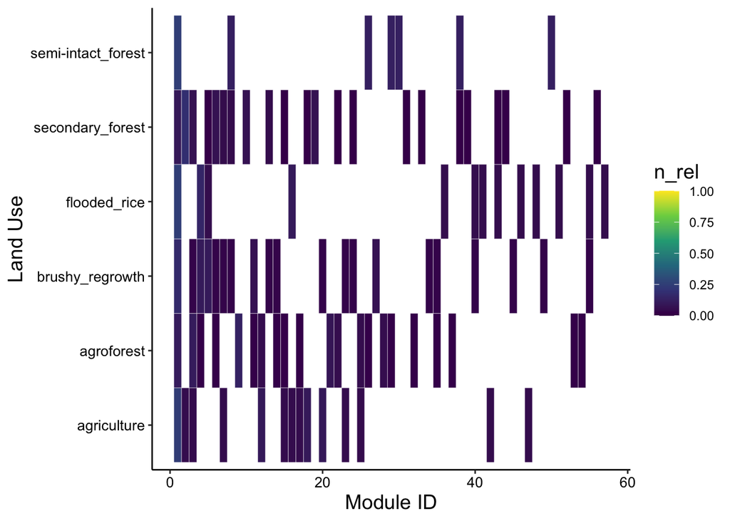

#### 1.1.3.3 Modules size

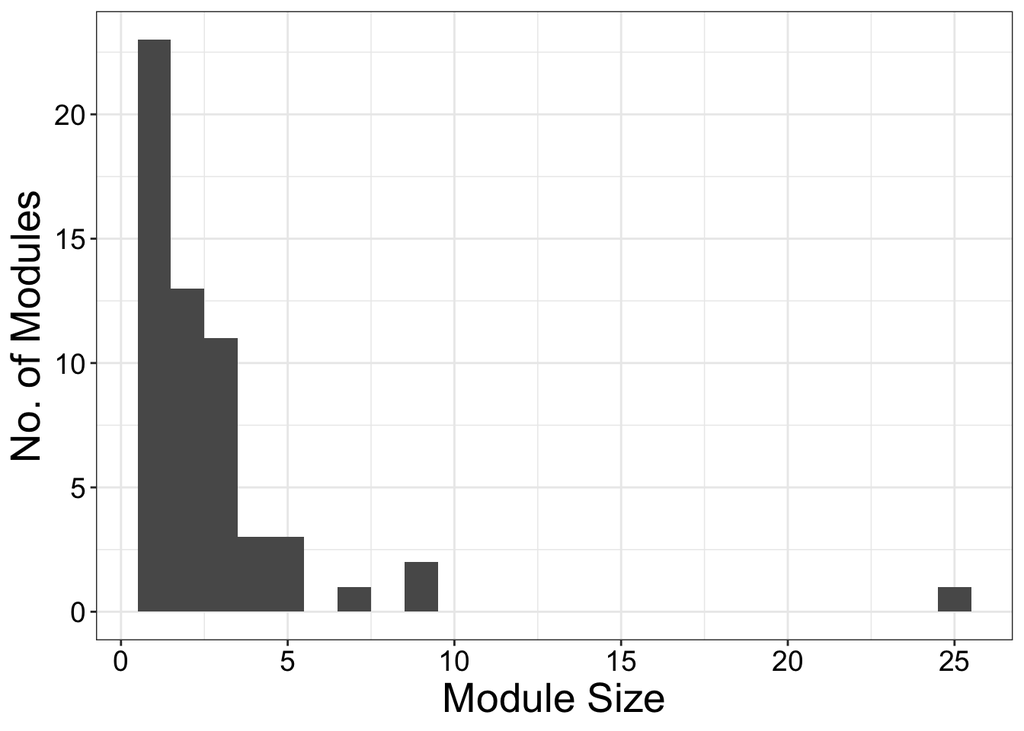

#### 1.1.3.4 No. of land uses

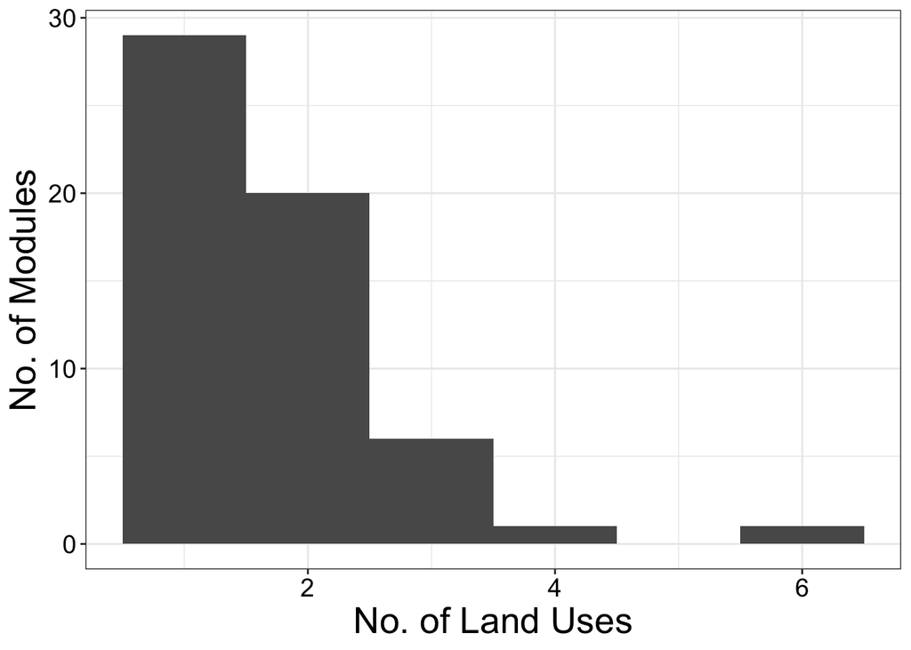

## 1.2 Normalized Mutual Information (NMI)

```r
# loop for three villages
for (j in 1:3) {

  cat('###',village_names[j],'{.tabset}','\n','\n')

  cat('#### NMI','\n')
  print(nmi_observed_three_villages[[j*2]])
  cat('\n','\n')

  cat('#### NMI for core/non-core','\n')
  print(nmi_diff_core_three_villages[[j]])
  cat('\n','\n')
}
```

### 1.2.1 Mandena

#### 1.2.1.1 NMI

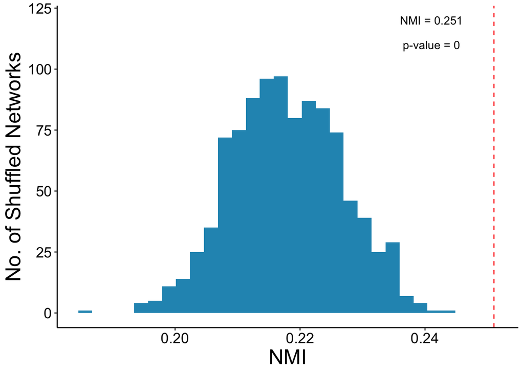

#### 1.2.1.2 NMI for core/non-core

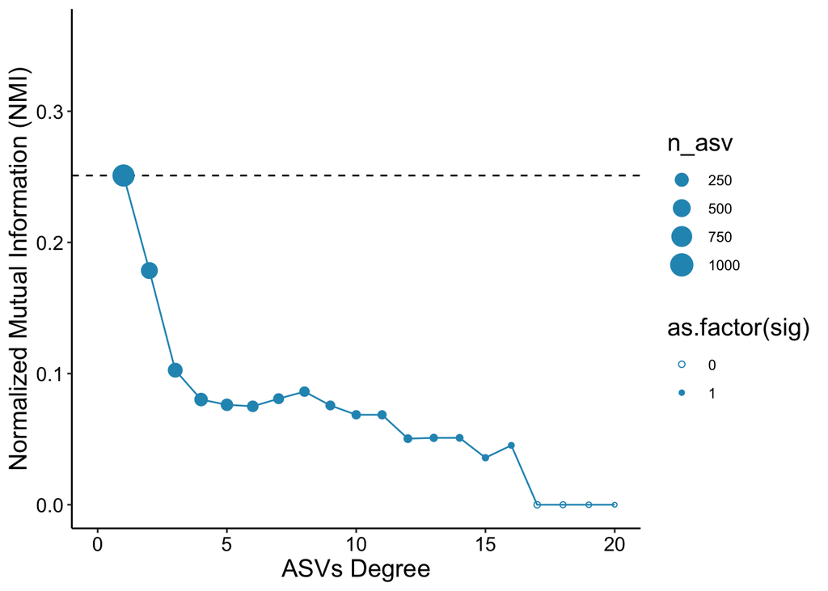

### 1.2.2 Sarahandrano

#### 1.2.2.1 NMI

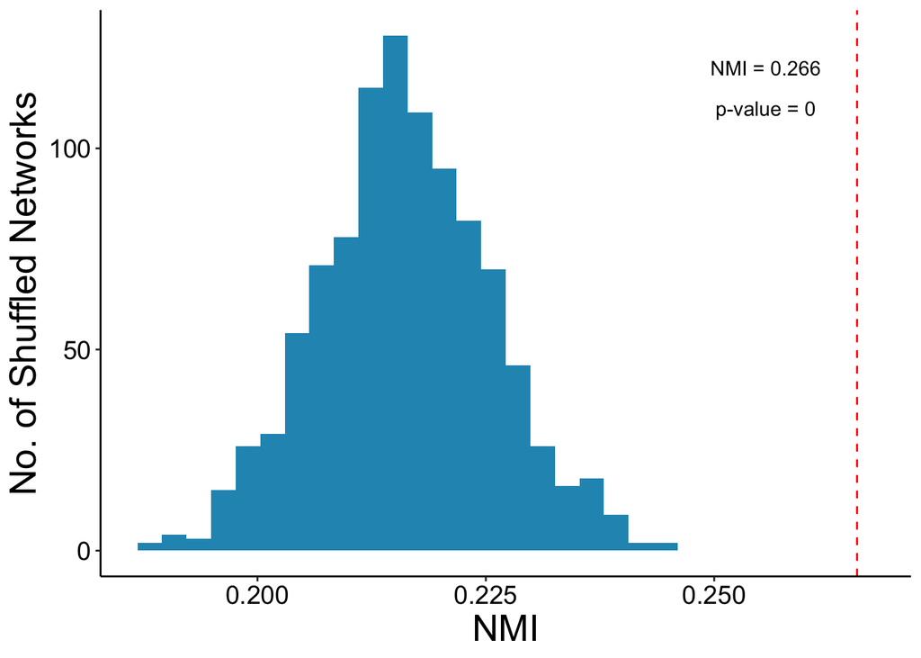

#### 1.2.2.2 NMI for core/non-core

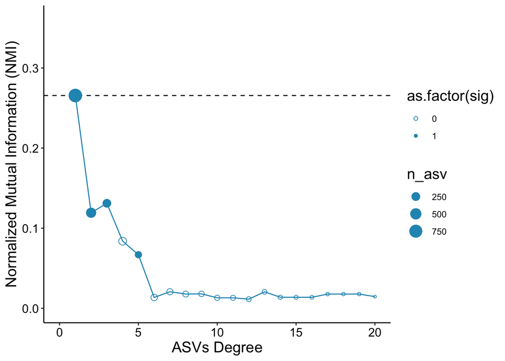

### 1.2.3 Andatsakala

#### 1.2.3.1 NMI

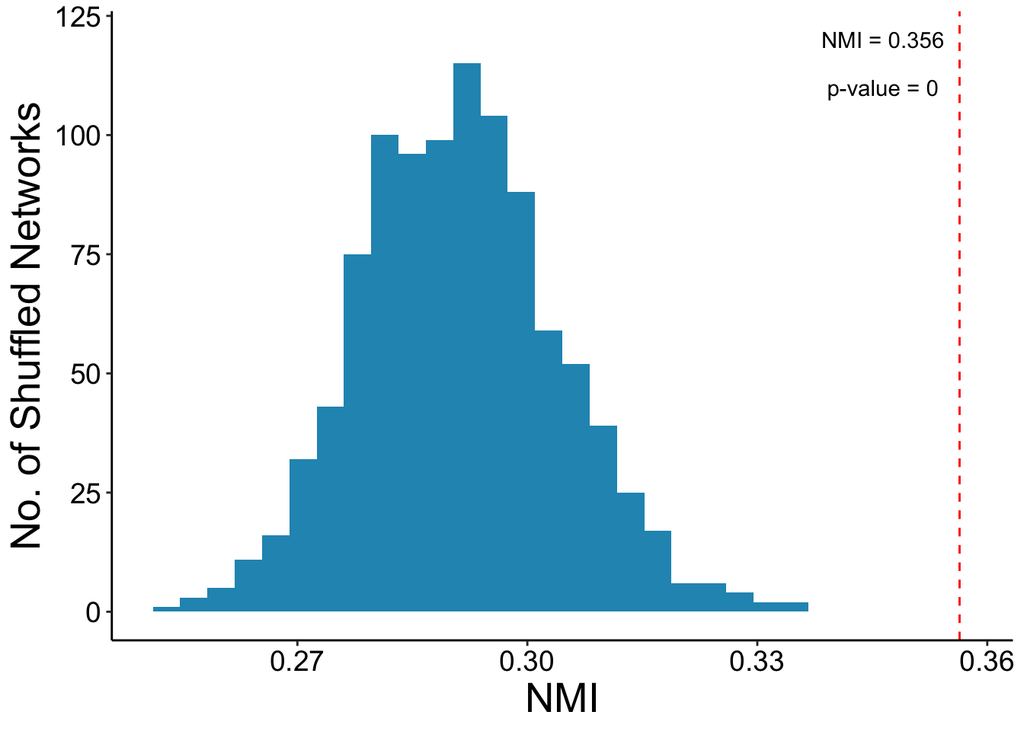

#### 1.2.3.2 NMI for core/non-core

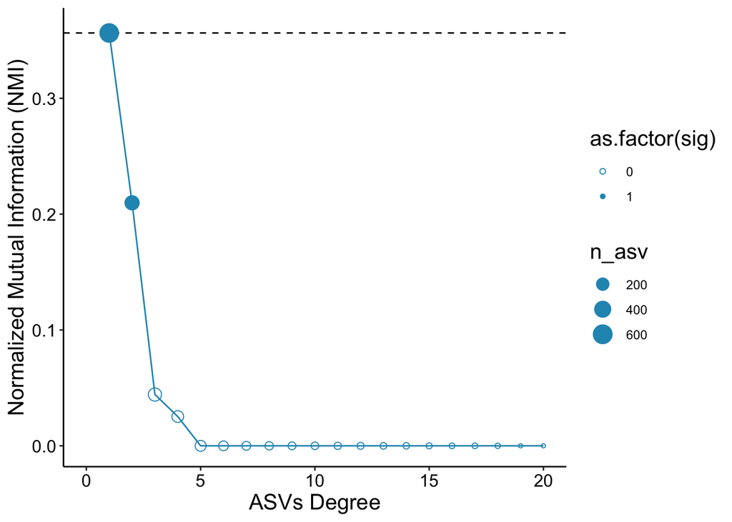

# 2 Hypotheses testing

```r
# reading grid similarity results
grids_similarity_attr <- read_csv("../data/data_processed/village_summary2.csv")

# combining the variables
final_data <- modules_similarity_three_villages %>%
  left_join(grids_similarity_attr, by=c("village","grid1","grid2")) %>%
  mutate(village = as.factor(village)) %>%
  filter(grid1!="village") # removing the village grid

# saving the final table
#write_csv(final_data, "data/data_processed/final_modularity_data.csv")
```

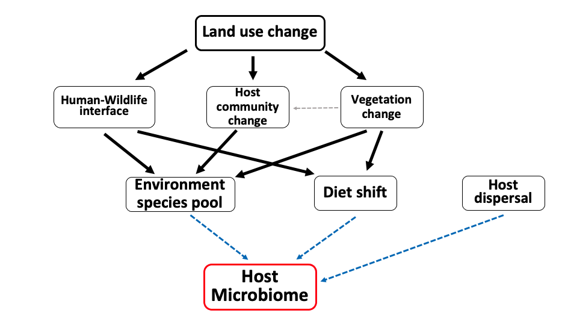

I explore 4 non-mutual exclusive hypotheses for why land use affects the network’s modular structure:

1. **Random process** - stochastic processes such as priority effect or just sampling error lead to random turnover of microbes and modules across grids. Therefore, no variable explains modules similarity.
2. **environmental filtering** - grid attributes (vegetation) induce selective pressure. Therefore, grids with similar vegetation attributes have higher modules similarity.
3. **Rattus movement** - Rattus individuals can move between grids. Therefore, closer grids have higher modules similarity.
4. **Microbes reservoir** - microbes of other host species constitute a microbes reservoir in the grid. Therefore, grids with similart small mammals communities have higher modules similarity.

## 2.1 The model

I used a linear mixed model (LMM) with ‘modules similarity’ as response variable and (1) ‘grid attributes similarity, (2) ’grids distance’, and (3) ‘small mammals community similarity’ as predictors. I added the ‘village’ as random factor.

```r
# setting the full model
library(nlme)
full_model <- lme(module_similarity ~ grid_attr + grid_dist + sm_community, random=~1|village, data = final_data, method = "ML", na.action = na.fail)
# r.squaredGLMM(full_model)

# checking normality assumption
#shapiro.test(residuals(full_model))
#qqnorm(residuals(full_model))
#qqline(residuals(full_model))
```

## 2.2 Correlations between variables

### 2.2.1 Correlations

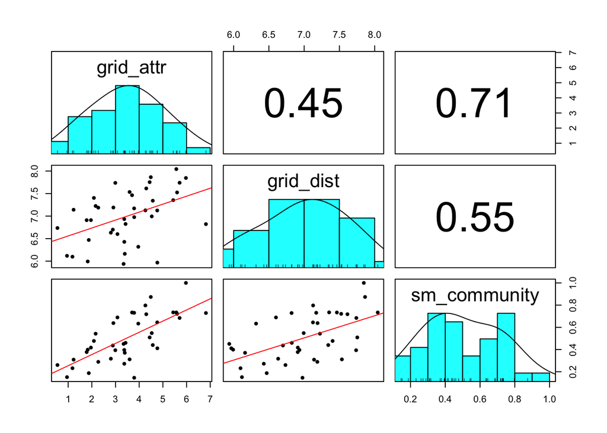

```r
# correlations between variables
library(psych)
print(psych::pairs.panels(final_data %>% filter(grid1!="village") %>%  select(-village,-grid1,-grid2, -module_similarity), ellipses = F, lm = T))
```

NULL

### 2.2.2 VIF

Variance Inflation Factor (VIF) - is a measure used in regression analysis to assess multicollinearity among predictor variables.  
VIF quantifies how much the variance of an estimated regression coefficient is increased due to multicollinearity. It is calculated for each predictor variable by regressing it against all other predictor variables in the model.  
A VIF value of 1 indicates no multicollinearity, while higher values indicate increasing levels of multicollinearity. **A common rule of thumb is that a VIF > 10 indicates problematic multicollinearity**.

```r
# checking VIF
# as a rule of thumb, VIF< 10 for a variable is fine
library(car)
print(knitr::kable(car::vif(full_model)))
```

|  | x |
| --- | --- |
| grid_attr | 2.215409 |
| grid_dist | 1.530495 |
| sm_community | 2.592229 |

## 2.3 Linear regression

### 2.3.1 Grid attributes

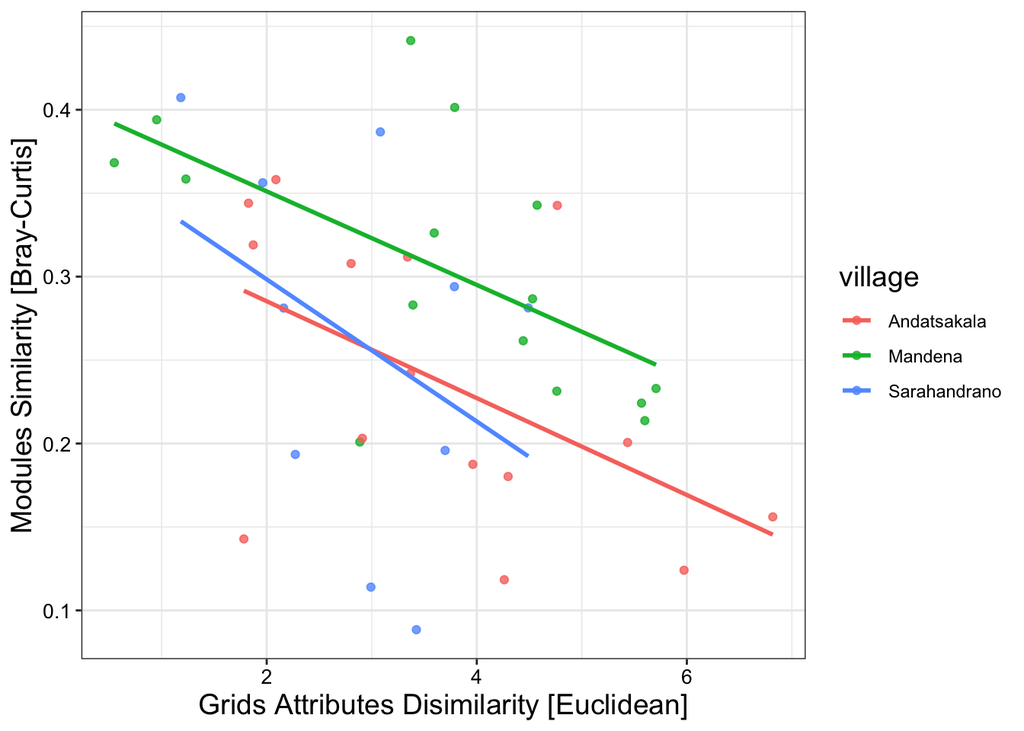

```r
# grid attributes
final_data %>%
  ggplot(aes(y=module_similarity, x=grid_attr, color=village)) +
  geom_point(alpha = 0.8) +
  geom_smooth(method = "glm", se=F, method.args = list(family = "gaussian")) +
  theme_bw() +
  theme(axis.text = element_text(size = 10, color = 'black'), title = element_text(size = 14), strip.text.x = element_text(size=12)) +
  labs(x = "Grids Attributes Disimilarity [Euclidean]", y = "Modules Similarity [Bray-Curtis]")
```

### 2.3.2 Distance

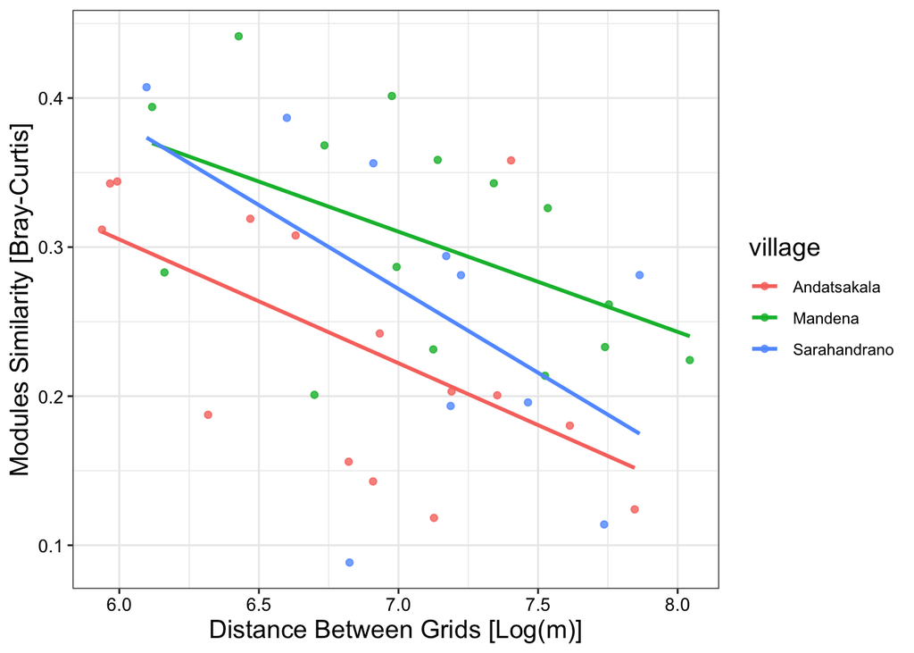

```r
# grid distance
final_data %>%
  ggplot(aes(y=module_similarity, x=grid_dist, color=village)) +
  geom_point(alpha = 0.8) +
  geom_smooth(method = "glm", se=F, method.args = list(family = "gaussian")) +
  theme_bw() +
  theme(axis.text = element_text(size = 10, color = 'black'), title = element_text(size = 14), strip.text.x = element_text(size=12)) +
  labs(x = "Distance Between Grids [Log(m)]", y = "Modules Similarity [Bray-Curtis]")
```

### 2.3.3 Small mammals community

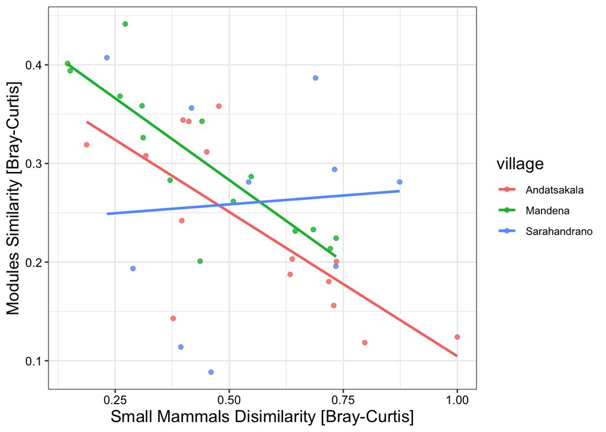

```r
# small mammals similarity
final_data %>%
  ggplot(aes(y=module_similarity, x=sm_community, color=village)) +
  geom_point(alpha = 0.8) +
  geom_smooth(method = "glm", se=F, method.args = list(family = "gaussian")) +
  theme_bw() +
  theme(axis.text = element_text(size = 10, color = 'black'), title = element_text(size = 14), strip.text.x = element_text(size=12)) +
  labs(x = "Small Mammals Disimilarity [Bray-Curtis]", y = "Modules Similarity [Bray-Curtis]")
```

## 2.4 Model selection

```r
# AIC
library(MuMIn)
dredge_modules_similarity <- MuMIn::dredge(full_model)
```

### 2.4.1 Table

```r
# The best models: delta <= 5
results_modules_similarity <- subset(dredge_modules_similarity, delta <= 5 | df == 3 | df == max(df), recalc.weights = FALSE)
row.names(results_modules_similarity) <- c(1:(nrow(results_modules_similarity)))

# arranging the final table
aic_results_final <- as.data.frame(results_modules_similarity) %>%
  select(-df, -logLik) %>%
  dplyr::rename(intercept='(Intercept)', grid_attributes=grid_attr, grid_distance=grid_dist, sm_similarity=sm_community) %>%
  mutate(across(everything()), round(.,3))
print(knitr::kable(aic_results_final))
```

| intercept | grid_attributes | grid_distance | sm_similarity | AICc | delta | weight |
| --- | --- | --- | --- | --- | --- | --- |
| 0.391 | NA | NA | -0.245 | -83.951 | 0.000 | 0.352 |
| 0.625 | NA | -0.038 | -0.175 | -83.093 | 0.858 | 0.229 |
| 0.720 | -0.019 | -0.055 | NA | -82.000 | 1.950 | 0.133 |
| 0.398 | -0.007 | NA | -0.211 | -81.683 | 2.268 | 0.113 |
| 0.635 | -0.008 | -0.039 | -0.127 | -80.794 | 3.157 | 0.073 |
| 0.821 | NA | -0.079 | NA | -80.474 | 3.477 | 0.062 |
| 0.367 | -0.029 | NA | NA | -79.417 | 4.533 | 0.037 |
| 0.267 | NA | NA | NA | -71.729 | 12.222 | 0.001 |

### 2.4.2 Variables Importance

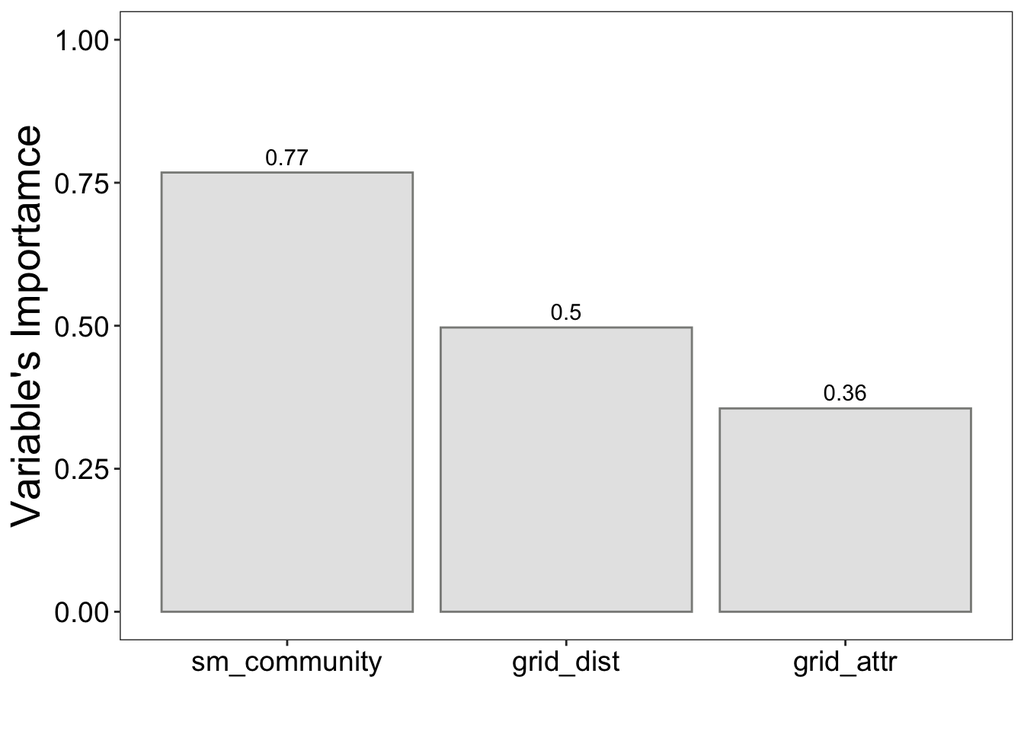

```r
imp <- as.data.frame(MuMIn::sw(dredge_modules_similarity))
colnames(imp) <- "importance"
var_names <- rownames(imp)
imp_values <- as.vector(imp[[1]])

# Plotting
g <- imp %>%
  rownames_to_column("variable") %>%
  mutate(variable = factor(variable)) %>%
  ggplot(aes(x=reorder(variable,-importance), y=importance)) +
    geom_bar(stat="identity", fill = "#e5e5e5", color="#8b8c89") +
    theme_bw() +
    scale_y_continuous(limits = c(0, 1)) +
    theme(axis.text = element_text(size = 14, color = 'black'), title = element_text(size = 20), strip.text.x = element_text(size=12), legend.position="none",
          panel.grid.major = element_blank(),
    panel.grid.minor = element_blank()) +
  geom_text(aes(label=round(importance,2)), vjust=-0.5) +
 # annotate(geom = "text", x=imp$variable, y=imp$importance, label=imp$importance) +
    labs(x="", y="Variable's Importamce")
print(g)
```

# 3 Phylogenetic analysis

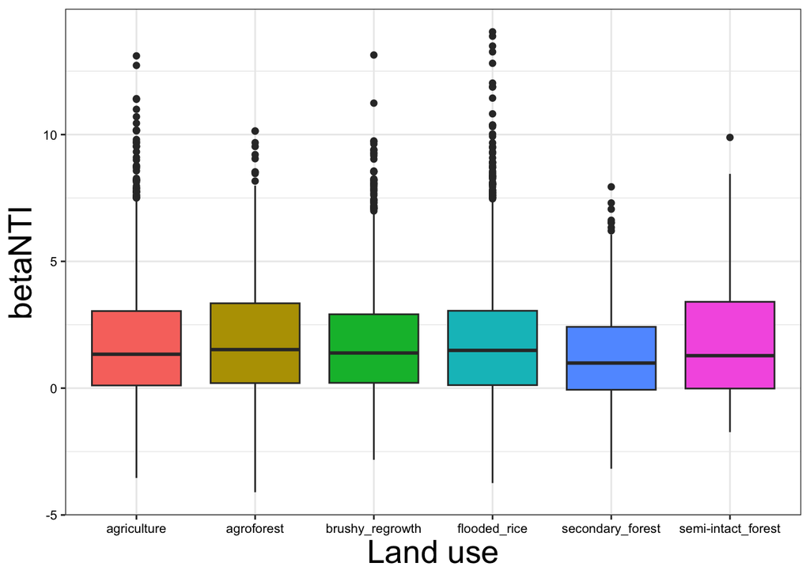

```r
library(ape)
library(picante)

# reading the phylogenetic tree
best_tree <- readRDS(file = "../results/phylo_tree_0.01_2.rds")
phylo_tree <- best_tree$tree

###########################################################################
# function to calculate beta-NTI

fun_calc_betaNTI <- function(dat_mat, phylo_dist, asv_pool) {

  n_modules <- nrow(dat_mat)
  n_asv <- ncol(dat_mat)

  # calculating observed MNTD
  mntd_obs <- as.matrix(picante::comdistnt(dat_mat, phylo_dist))

  mntd_shuff <- array(NA,dim = c(n_modules,n_modules,20))
  # loop for shuffling
  for (i in 1:20) {
    # randomly sampling ASVs from the ASV pool
    shuff_asv_names <- sample(asv_pool$asv_ID, n_asv, prob = asv_pool$p, replace = FALSE)
    # changing the cols names
    dat_mat_shuff <- dat_mat
    colnames(dat_mat_shuff) <- shuff_asv_names
    # calculating MNTD
    mntd_shuff[,,i] <- as.matrix(picante::comdistnt(dat_mat_shuff, phylo_dist))
  }

  # taking the mean and sd of the shuffled matrices
  mntd_shuff_mean <- apply(mntd_shuff,c(1,2),mean)
  mntd_shuff_sd <- apply(mntd_shuff,c(1,2),sd)

  # calculating betaNTI
  betaNTI_mat <- (mntd_obs - mntd_shuff_mean) / mntd_shuff_sd
  betaNTI_mat2 <- betaNTI_mat
  betaNTI_mat2[upper.tri(betaNTI_mat2)] <- NA
  diag(betaNTI_mat2) <- NA
  betaNTI <- melt(betaNTI_mat2) %>%
    filter(!(is.na(value))) %>%
    rename(module1 = Var1, module2 = Var2, betaNTI = value)

  return(betaNTI)
}

###########################################################################
# main script

# ASVs phylogenetic distance
asv_distance <- ape::cophenetic.phylo(phylo_tree)

# filter villages
data_asv_village <- read_csv("../data/data_processed/microbiome/data_asv_rra0.01_th1000_with_modules.csv") %>%
filter(host_species == "Rattus rattus" & grid!="village" & village == "Mandena")

# ASVs pool
asv_pool <- data_asv_village %>%
  distinct(asv_ID, asv_degree) %>%
  mutate(p = asv_degree/length(unique(data_asv_village$asv_ID)))

grids_names <- unique(data_asv_village$grid)
betaNTI_results <- NULL

# loop of grids
for (g in grids_names) {
  data_asv_grid <- data_asv_village %>% filter(grid == g)

  # transforming to a community matrix - rows = individuals, cols = ASVs
  data_asv_mat <- data_asv_grid %>%
    mutate(abundance = 1) %>%
    #filter(asv_degree > 5) %>%
    distinct(host_ID, asv_ID, abundance) %>%
    spread(asv_ID, abundance, fill = 0) %>%
    column_to_rownames("host_ID") %>%
    as.matrix()

  # calculating betaNTI
  betaNTI_results_grid <- fun_calc_betaNTI(data_asv_mat, asv_distance, asv_pool) %>%
    mutate(grid = g)
  betaNTI_results <- rbind(betaNTI_results, betaNTI_results_grid)

}

# plotting
betaNTI_results %>%
  left_join(data_asv_village %>% distinct(host_ID, host_group), by=c("module1"="host_ID")) %>% rename(host_group1=host_group) %>%
  left_join(data_asv_village %>% distinct(host_ID, host_group), by=c("module2"="host_ID")) %>% rename(host_group2=host_group) %>%
  filter(host_group1 != host_group2) %>%
  ggplot(aes(x=grid, y=betaNTI, fill=grid)) +
  geom_boxplot() +
  theme_bw() +
  theme(axis.text = element_text(size = 8, color = 'black'), title = element_text(size = 20), legend.position = "none") +
  labs(x="Land use", y="betaNTI")
```

```r
cat('\n','\n')
```